# Principal component analysis for University data

Romanova

26 октября 2018 г

Набор данных об американских университетах. В составе даных 44 признака, харакеризующих с разных сторон уровень обучающихся в университете, его пристижность, преподавателей и т.д. Признаков очень много, поэтому имеет смысл сразу разделить их на скоррелированные группы, в каждой из которых при помощи анализа главных компонент, получить новый признак (или, возможно, несколько интерпретируемых признаков). Также стоит учитывать, что многие признаки содержат большое колчесво NA. С этой проблемой можно бороться по-разному, здесь мы будем заменять пропуски на средние значения.

Известно, что данные сильно неоднородные по признаку PPIND, поэтому сразу будем рассматривать подгруппу государственных университетов, (PPIND=1), так как их больше, чем частных.

Взглянем на корреляционную матрицу между всеми признаками, чтобы понять, какие признаки образуют скоррелированные блоки.

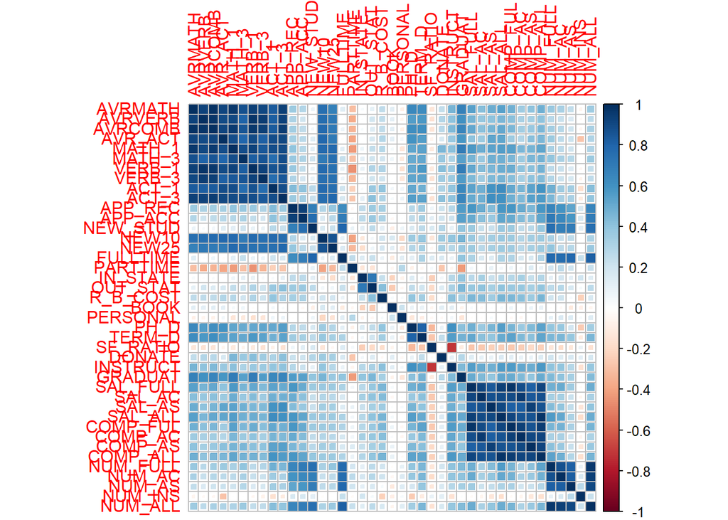

```r
corr1<-cor(PPIND1,use="pairwise.complete.obs")
corrplot(corr1, method = "square")
```

Первые 10 признаков – средние баллы студентов, обучающихся в университетах, по различным тестам. Проведем анализ главных компонент по этим 10ти признакам.

```r
pca.quality<-dudi.pca(Un1[,c(1:10)],nf=2,scannf = FALSE)
get_eigenvalue(pca.quality)
```

```
##          eigenvalue variance.percent cumulative.variance.percent
## Dim.1  7.106240e+00     7.106240e+01                    71.06240
## Dim.2  1.214472e+00     1.214472e+01                    83.20712
## Dim.3  9.289059e-01     9.289059e+00                    92.49617
## Dim.4  2.285390e-01     2.285390e+00                    94.78156
## Dim.5  1.963962e-01     1.963962e+00                    96.74553
## Dim.6  1.625102e-01     1.625102e+00                    98.37063
## Dim.7  8.989496e-02     8.989496e-01                    99.26958
## Dim.8  4.708695e-02     4.708695e-01                    99.74045
## Dim.9  2.591143e-02     2.591143e-01                    99.99956
## Dim.10 4.384585e-05     4.384585e-04                   100.00000
```

```r
pca.quality$c1
```

```
##                CS1        CS2
## AVRMATH -0.3312033 -0.1325725
## AVRVERB -0.3339139 -0.1894252
## AVRCOMB -0.3389016 -0.1607147
## AVR_ACT -0.2695481  0.4320621
## MATH_1  -0.3375343 -0.1696287
## MATH_3  -0.3214865 -0.1385474
## VERB_1  -0.3355126 -0.2297832
## VERB_3  -0.3326162 -0.2159238
## ACT_1   -0.2620764  0.5720853
## ACT_3   -0.2865767  0.5092755
```

Первая компонента – минус сумма всех показателей (при составлении матрицы новых признаков поменяем знак, чтобы было все хорошо). То есть это в каком-то смысле общий уровень знаний студентов. Вторая компонента показывает разницу между результатами теста ACT и всеми остальными тестами. Производим эту процедуру и с остальными признаками (не будем подробно на этом останавливаться).

```r
new.Univ<-data.frame(-pca.quality$li$Axis1,-pca.quality$li$Axis2)
colnames(new.Univ)<-c("quality","all&ACT")
new.Univ$applicants<--dudi.pca(Un1[,11:13],nf=1,scannf = FALSE)$li #приток студентов, количественная характеристика
new.Univ$super.students<--dudi.pca(Un1[,14:15],nf=1,scannf = FALSE)$li # процент отличников
new.Univ$num.students<-dudi.pca(Un1[,16:17],nf=1,scannf = FALSE)$li # количество студентов (количественная характеристика)
new.Univ$tuition<-dudi.pca(Un1[,18:19],nf=1,scannf = FALSE)$li # стоимость обучения
new.Univ$fees<--dudi.pca(Un1[,20:22],nf=1,scannf = FALSE)$li # затраты на общагу и предметы, необходимые для обучения и жизни в кампусе
new.Univ$competence<-dudi.pca(Un1[,23:24],nf=1,scannf = FALSE)$li # компетентность преподавателей
new.Univ$fs.ratio<-Un1[,25] # отношение числа преподавателей к числу студентов (чем больше, тем лучше)
new.Univ$donate<-Un1[,26] # процент успешных выпускников
new.Univ$instruct<-Un1[,27] # средства, выделяемые на одного ученика
new.Univ$graduate<-Un1[,28] # процент выпустившихся судентов
new.Univ$salary<--dudi.pca(Un1[,29:36],nf=1,scannf = FALSE)$li # заработок преподавателей
new.Univ$num.teachers<--dudi.pca(Un1[,37:41],nf=1,scannf = FALSE)$li # количество преподавателей (количественная характеристика)
new.Univ<-as.matrix(new.Univ)
new.Univ<-as.data.frame(new.Univ)
```

Таким образом составили матрицу новых признаков. Проведем для нее PCA.

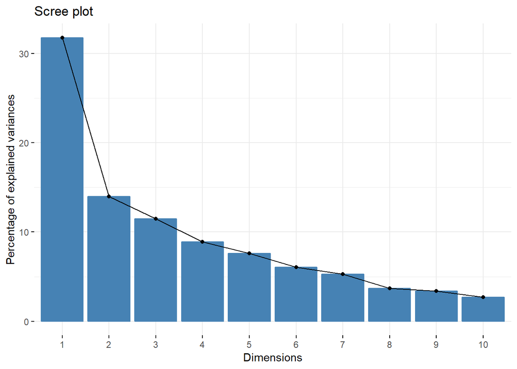

```r
res.pca<-dudi.pca(new.Univ,nf=14,scannf = FALSE)
fviz_eig(res.pca)
```

Собственные числа ($\lambda_{i}$):

```r
get_eigenvalue(res.pca)
```

```
##        eigenvalue variance.percent cumulative.variance.percent
## Dim.1   4.4520658       31.8004699                    31.80047
## Dim.2   1.9596639       13.9975990                    45.79807
## Dim.3   1.6096441       11.4974577                    57.29553
## Dim.4   1.2450587        8.8932763                    66.18880
## Dim.5   1.0659438        7.6138842                    73.80269
## Dim.6   0.8498480        6.0703427                    79.87303
## Dim.7   0.7383369        5.2738347                    85.14686
## Dim.8   0.5141874        3.6727672                    88.81963
## Dim.9   0.4727893        3.3770667                    92.19670
## Dim.10  0.3781401        2.7010004                    94.89770
## Dim.11  0.2636964        1.8835460                    96.78124
## Dim.12  0.2056622        1.4690156                    98.25026
## Dim.13  0.1329141        0.9493864                    99.19965
## Dim.14  0.1120494        0.8003531                   100.00000
```

Первые 5 собственных чисел больше единицы. Пять первых компонент объясняют 73.8% дисперсии. На scree plot не совсем понятно, с какого момента камни начинают сыпаться, но, скорее всего, это все же 3 компоненты. Как будет позже показано, более менее интерпретируются тоже только три первые компоненты. Однако было принято решение использовать 5 компонент, так как 3 компоненты объясняют только 57% разброса, а хочется побольше.

Собственные векторы ($U_{i}$):

```r
res.pca$c1
```

```
##                        CS1         CS2          CS3         CS4
## quality         0.32269309  0.25193198  0.302764880 -0.13027533
## all&ACT        -0.05870133  0.14899874  0.163601636  0.18874787
## applicants      0.31994644 -0.40516770  0.170177712  0.08313019
## super.students  0.26831735  0.24324884  0.375398193 -0.23949716
## num.students    0.11071782 -0.60062239 -0.143923945 -0.11501228
## tuition         0.21101221 -0.02861082 -0.157003052  0.60249790
## fees            0.05475047 -0.03952063 -0.194968277 -0.64245317
## competence      0.34388822  0.11214784 -0.122101128 -0.10572996
## fs.ratio        0.16774962  0.31254028 -0.530216229  0.01428660
## donate          0.16587470  0.09045041  0.358963139 -0.08653707
## instruct        0.34597225  0.22429958 -0.393134759 -0.05119330
## graduate        0.35143598  0.05598976  0.188802524  0.25251408
## salary          0.35977574 -0.01341041 -0.114897830  0.04567618
## num.teachers    0.33425306 -0.39472300 -0.003416613 -0.08254342
##                         CS5          CS6          CS7          CS8
## quality        -0.025979756  0.222577758  0.141835798  0.037132659
## all&ACT         0.794156099 -0.265301622  0.298203751  0.286126669
## applicants      0.033837402 -0.080264175  0.102215829 -0.069605988
## super.students  0.212031530  0.137282640 -0.009702634 -0.460541231
## num.students    0.261014989  0.012577803 -0.115819063  0.113416382
## tuition        -0.245574229 -0.302062038  0.225688419 -0.112630735
## fees           -0.175665939 -0.418658209  0.525796627  0.004788535
## competence     -0.069809765  0.289926692 -0.203743319  0.658098933
## fs.ratio        0.259242145 -0.152391615 -0.261837931 -0.236629341
## donate         -0.143488219 -0.685534276 -0.493324280  0.221167991
## instruct        0.068861180 -0.050417115 -0.085906511 -0.097381642
## graduate       -0.179355075  0.009426941  0.168324705 -0.059502134
## salary          0.005696035  0.086377307  0.323010200  0.228121248
## num.teachers    0.183394226  0.027950494 -0.214745176 -0.266780181
##                         CS9        CS10        CS11        CS12
## quality        -0.033784299  0.51057416  0.43102035 -0.36630735
## all&ACT         0.156980242  0.02921740 -0.03948766  0.01518958
## applicants      0.075166565 -0.29634257 -0.36732376 -0.54623516
## super.students -0.182642479  0.04043885 -0.37623401  0.38111679
## num.students   -0.084411912  0.21683502  0.30645776  0.38605435
## tuition        -0.084769423  0.51242564 -0.23850472  0.14654787
## fees            0.183986975  0.09713996 -0.05849074  0.01380135
## competence      0.236308780  0.13973868 -0.38958699  0.06062425
## fs.ratio        0.007733988 -0.01587864  0.16889627 -0.33281425
## donate         -0.177032162 -0.04900446  0.09745935  0.03413776
## instruct        0.083091803 -0.16834245 -0.05927196  0.23026351
## graduate        0.527680222 -0.37605924  0.40513208  0.26801289
## salary         -0.702895704 -0.33169520  0.15437401  0.01891516
## num.teachers    0.142793656  0.16736371  0.02612614 -0.10219902
##                       CS13         CS14
## quality        -0.25761309  0.062431624
## all&ACT        -0.01248613 -0.112503834
## applicants     -0.22314624  0.313303646
## super.students  0.14898449  0.224866307
## num.students   -0.11264997  0.434397168
## tuition         0.04746486  0.038116731
## fees            0.12313509  0.001513284
## competence      0.21277643  0.058685046
## fs.ratio        0.35408581  0.335980746
## donate         -0.01956212 -0.018511016
## instruct       -0.71674551 -0.207769931
## graduate        0.20719851  0.105148548
## salary          0.19091148 -0.162803543
## num.teachers    0.25932221 -0.668704618
```

Первые две компоненты удобно интерпретировать при помощи следующего графика.

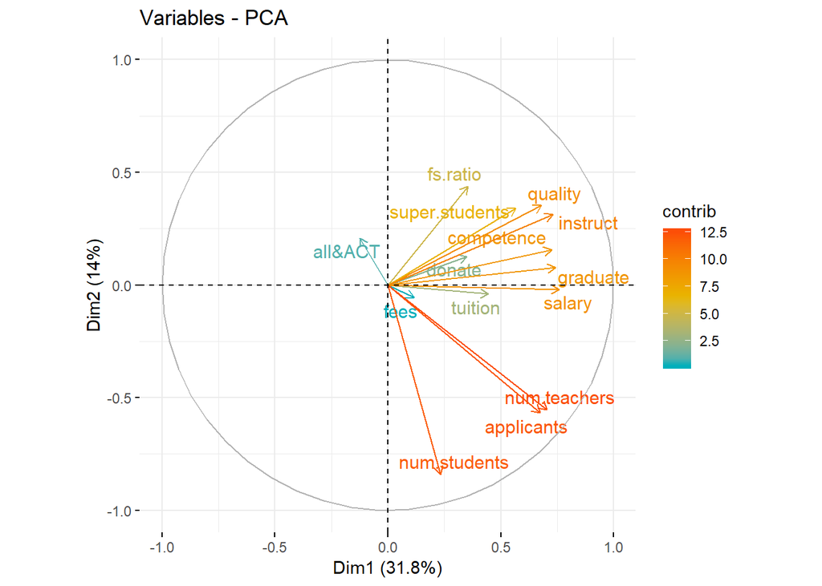

```r
fviz_pca_var(res.pca,
             col.var = "contrib",
             gradient.cols = c("#00AFBB", "#E7B800", "#FC4E07"),
             repel = TRUE
             )
```

Первая компонента суть общий уровень университета. Вторая компонента – разница, между размером университета и различными показателями качества. С последующими главными компонентами сложнее (опять смотрим на собственные векторы), 3ю главную компоненту можно с натяжкой интерпретировать как разницу между востребованностью вуза у талантливых студентов и материальными аспектами обучения. То есть это, в какой-то мере, характеристика хороших, но не очень выпендрежных и процветающих вузов. 4я компонента – разница между стоимостью обучения в вузе и объемом дополнительных расходов (соответствующие переменные дают примерно одинаковый вклад 0.6), при этом с учетом разницы между процентом отличников и процентом студентов, сумевших дойти до конца обучения (обе компоненты дают вклад около 0.3).

На следующем графике индивиды нарисованы в плоскости первых двух главных компонент.

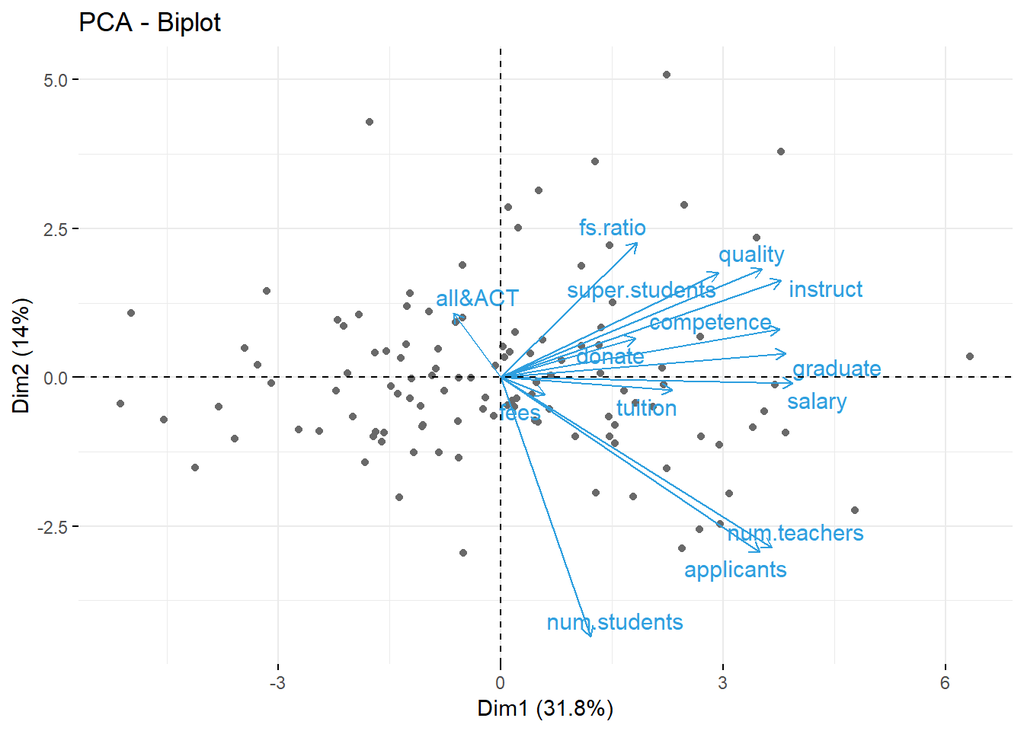

```r
fviz_pca_biplot(res.pca, repel = TRUE,
                col.var = "#2E9FDF",
                col.ind = "#696969",
                label = "var"
                )
```